# Trend Report Addendum

Kevin Gilds, MPA

2016-05-24

# Introduction:

The following report reflects slight increases in percent achievement in academic data from the May 1st submission. The changes reflect a change in the number of successful matches, and this impacted the denominator when calculating percent achievement.

This report also has trend data from students who participated in the Get REAL! program last year. The number of students that could be matched is 68 and most have very positive outcomes. Nearly 2/3 have increased grades or maintained at least a C average in Language Arts. Almost 100% have decreased or reduced suspensions and 81 percent have improved their attendance.

# Objectives:

# Reading Improvement:

## Objective:

*50% of participating students will improve their reading skills as demonstrated by their Language Arts grade increasing or maintaining a “C” grade from the baseline grading period to the final grading period as evidenced by report cards/school reports.*

### Language Arts Grade: % of Students that increased Grade or maintained a C

The number of students that could be matched from Quarter 1 to Quarter 2 is **506**, and the percent of students that increased their grade or maintained a C is **74.31%**. The mean difference between grades is Q1 to Q2 is *0.1166*.

### Grade Change Plot from Q1 to Q2:

The changes in grades from Q1 to Q2 is represented below. The vertical axis represents Q1 grades and the bottom axis the change from Q1. Thus ideally we want to see circles moving to right. Note that,students with an A in Q1 can decrease but not increase.

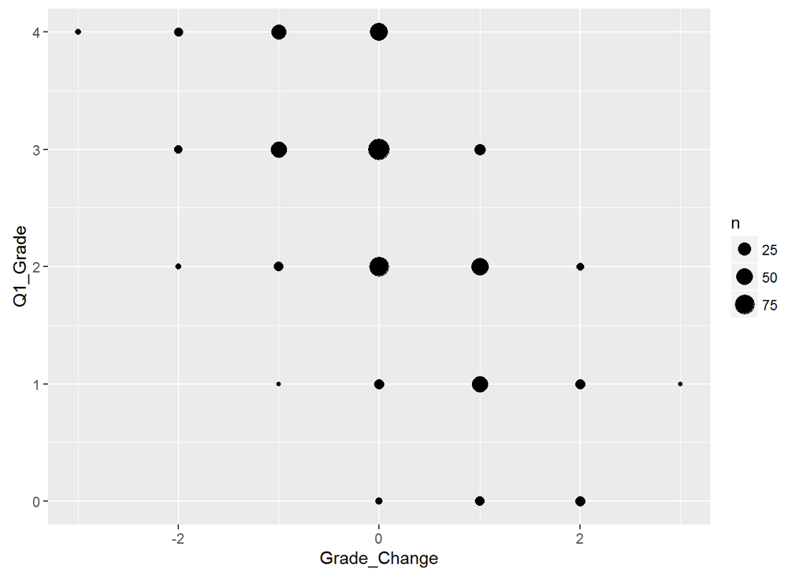

### Trend Data Q4 2015 to Q2 2016:

### % of students who increased Language Arts Grade or maintained a C grade:

The number of students that could be matched from Quarter 4 to Quarter 2 is **68**. The number of students that increased their grade or maintained a C is **58.82%**. The mean difference between the two quarters is *-0.1397*.

### Plot change in Grade from Quarter 4 to Quarter 2:

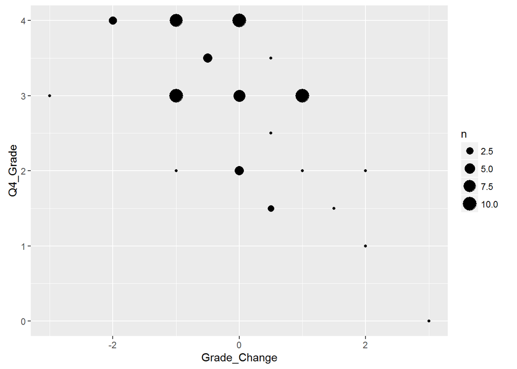

### Reading Success: % of Students that increased Grade or maintained a C

The number of matching students from Quarter 1 and Quarter 2 is **246**, and the percent of students who increased their reading grade is **75.2 %**.

### GPA Difference between Q1 and Q2:

The reading gpa for students is **2.55**,and the average reading grade difference is *0.126*.

### Reading Grades Plots:

The changes in grades from Q1 to Q2 is represented below. The vertical axis represents Q1 grades and the bottom axis the change from Q1. Thus ideally we want to see circles moving to right. Note,students with an A in Q1 can decrease but not increase.

### Reading Grade Change from Q1 to Q2:

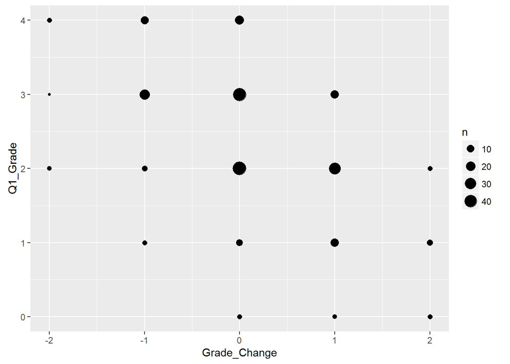

## Reading Trend Data:

The number of students that could be matched from last year is **19**, and the current reading gpa for students who particpated last year is **2.47**. The percent of studuents of who increased their grade or maintained their grade is **42.11%**,and the average difference between Q4 2015 and Q2 is **-0.68**.

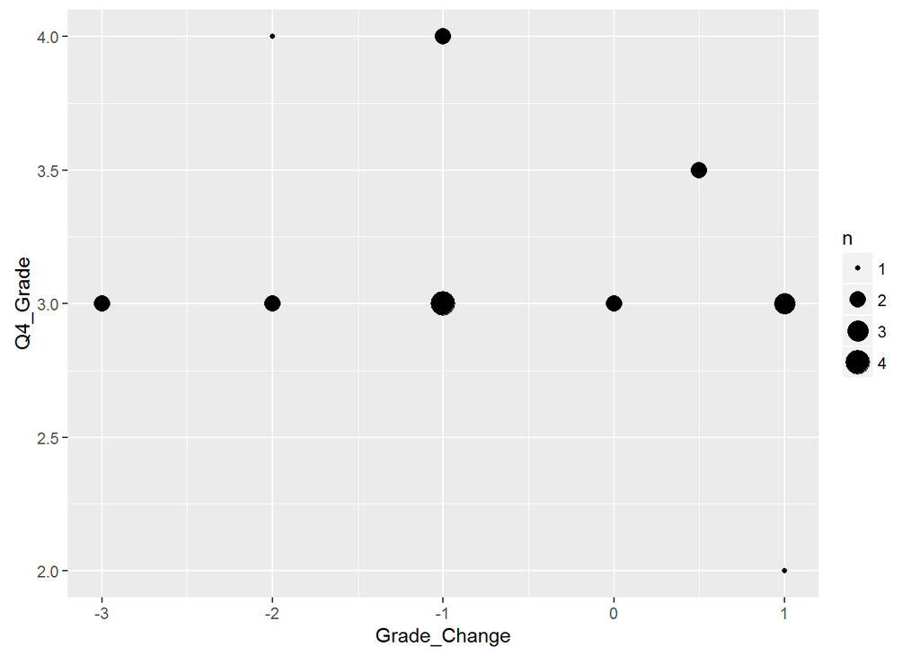

# Improved Attendance:

## Objective:

*60% of participating students will either maintain or improve their attendance rates as demonstrated by their decreased absences from the baseline grading period to the final grading period as evidenced by report cards/school reports.*

### Absences Success: % of Students who decreased their absences or had no absences.

The number of valid entries is **507**, and the number of students who decreased their absences or did not miss any days is **62.72%**. The average difference of absences between Quarter 1 and Quarter 2 is *-0.284*.

### Absences Change Table:

| -10 | -8 | -7 | -6 | -5 | -4 | -3 | -2 | -1 | 0 | 1 | 2 | 3 | 4 | 5 | 6 | 9 |
| --- | --- | --- | --- | --- | --- | --- | --- | --- | --- | --- | --- | --- | --- | --- | --- | --- |
| 2 | 4 | 3 | 5 | 10 | 19 | 24 | 47 | 99 | 137 | 51 | 57 | 25 | 15 | 7 | 1 | 1 |

### Plot of Change in Absences:

The plot below has the council on the vertical axis and the difference in absences between Quarter 1 and Quarter 2. For this plot it is good to see the circles on the left to reflect decreases.

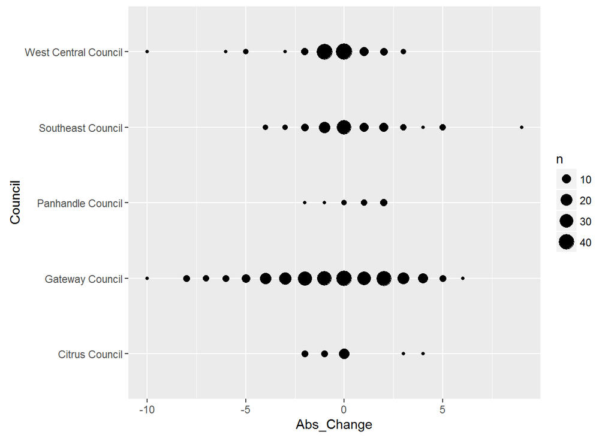

### Trend Data

The number of students that could be matched is **69**, and the mean attendance change from Quarter 4 to Quarter 2 is **0.14**. The vast majority of students are improving their attendance rates. The mean difference is reflecting three students with a high number of absences. The percent of students who have improved their attendance from Quarter 4 last year is **81.16%**

### Plot of Absences Change by Council:

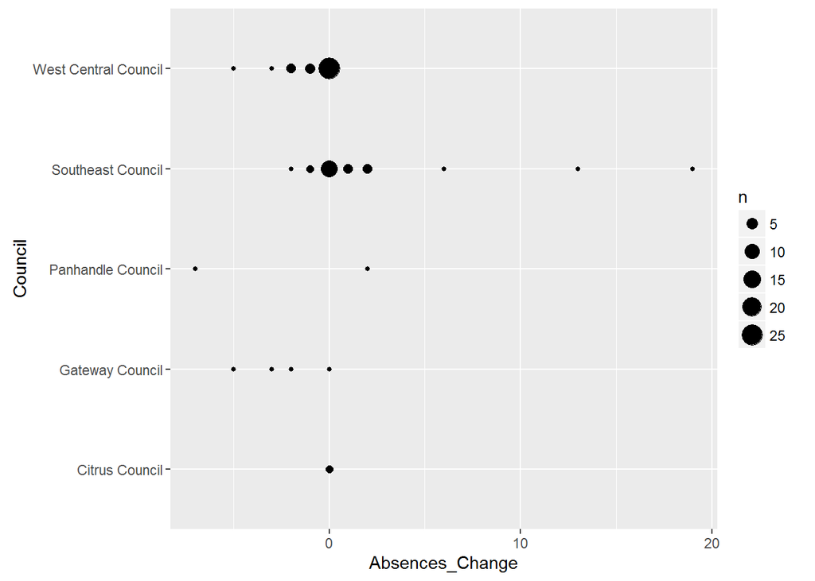

### Plot change in absence by Student:

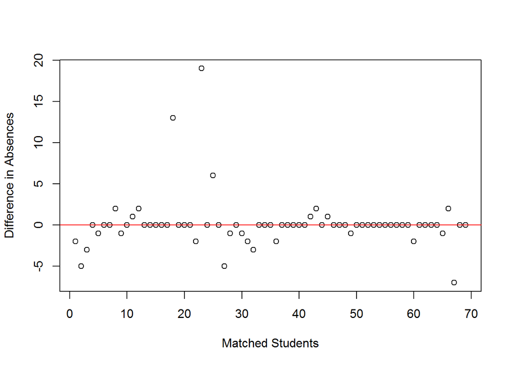

# Improvement In School Behavior:

## Objective:

*70% of participating students will show improvement in behavior by decreasing their number of suspensions from the baseline grading period to final grading period or not having a suspension during the school year as evidenced from the student’s report card/school reports.*

### Suspensions: % of students who reduced the number of supsensions or never received a suspsenion

| -7 | -5 | -4 | -3 | -2 | -1 | 0 | 1 | 2 | 3 | 4 | 5 | 6 | 20 | 24 |
| --- | --- | --- | --- | --- | --- | --- | --- | --- | --- | --- | --- | --- | --- | --- |
| 1 | 4 | 2 | 4 | 10 | 23 | 404 | 26 | 11 | 12 | 6 | 1 | 1 | 1 | 1 |

The number of the valid entries is **507**, and the percent of students who have decreased their suspensions or did not have any suspensions is **87.57%**. The average difference of suspensions between Quarter 1 and Quarter 2 is *0.144*

### Suspensions Change Plots from Quarter 1 to Quarter 2:

The plot below reflects that their has been an increase in suspensions from Quarter 1 to Quarter 2. The council is on the vertical axis and the suspensions change is on the bottom axis. The desire is for the circles to be on the left.

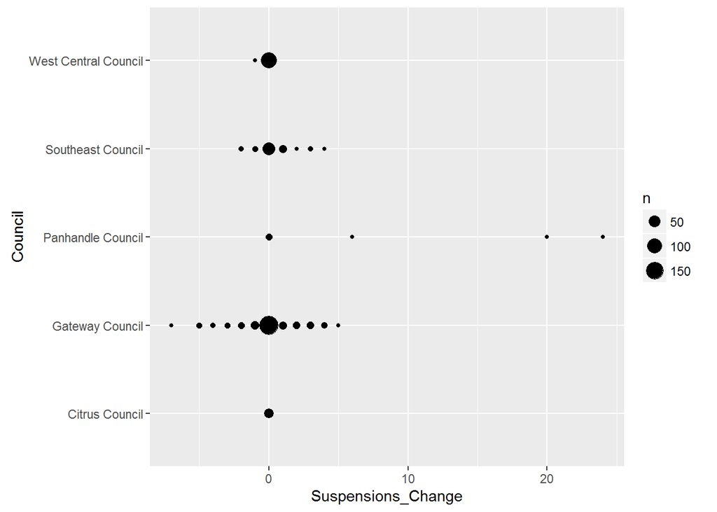

### Trend Data:

### Trend Data Q4 2015 to Q2 2016:

The number of students that could be matched from Quarter 4, 2015 is **68**. The mean difference between Quarter 4 2015 and Quarter 2 2016 is **-0.13**. The percent of students who decreased their number of suspensions from Quarter 4 to Quarter 2 or never received a suspension is **98.53%**.

### Plot of differences in Suspensions by Council:

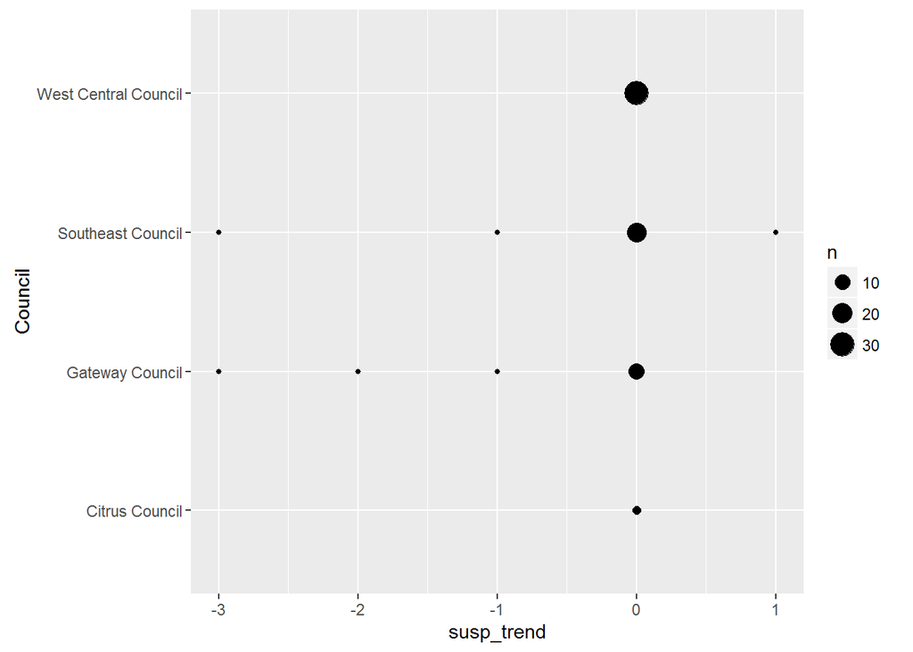

### Plot of differences in Suspensions by student:

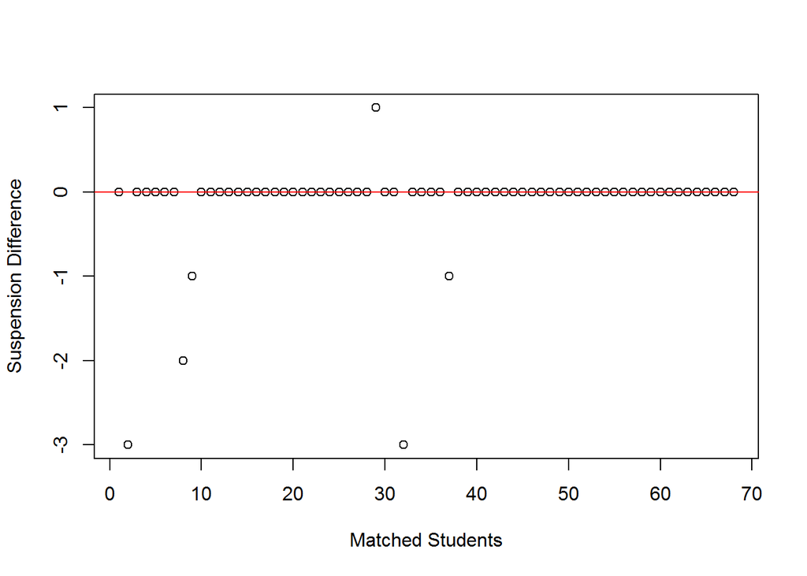